# Chap3Exercises

Sanjeev Gadre

August 1, 2018

Including the necessary libraries

```r
library(ISLR)
library(car)
library(tidyverse)
```

## Problem 13

# 13.a

```r
set.seed(1)
x = rnorm(100)
```

# 13.b

```r
eps= rnorm(100,0,sqrt(0.25))
```

# 13.c

```r
y = -1+0.5*x+eps
```

The length of vector y is 100 and the values of beta_0 and beta_1 in this linear model are respectively -1 and 0.5.

# 13.d

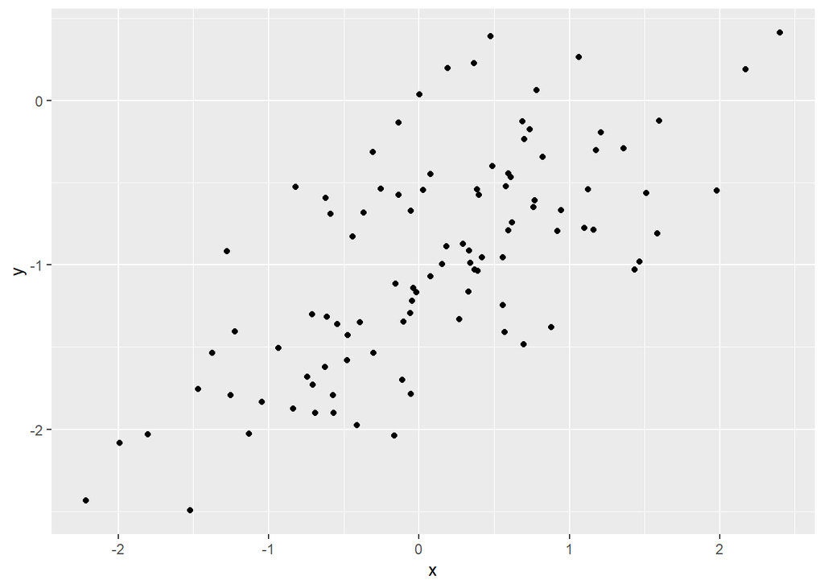

```r
data.frame(y=y, x=x) %>% ggplot(aes(x,y))+ geom_point()
```

The scatter plot seems to indicate that y increases monotonically with x, something we expect because of the model definition. However the noise term (eps) means that y’s are not on a straight line but scattered about.

# 13.e

```r
linear_fit_13e = lm(y~x)
summary_13e = summary(linear_fit_13e)
beta_hat_0_13e = summary_13e$coefficients[1]
beta_hat_1_13e = summary_13e$coefficients[2]
R_sq_13e = summary_13e$r.squared
```

The beta_hat_0 value of

```
## [1] -1.02
```

is very close to beta_0 -1 and similarly the beta_hat_1 value of

```
## [1] 0.499
```

is very close to beta_1 of 0.5. The differences are attributable to the noise term eps. #13.f

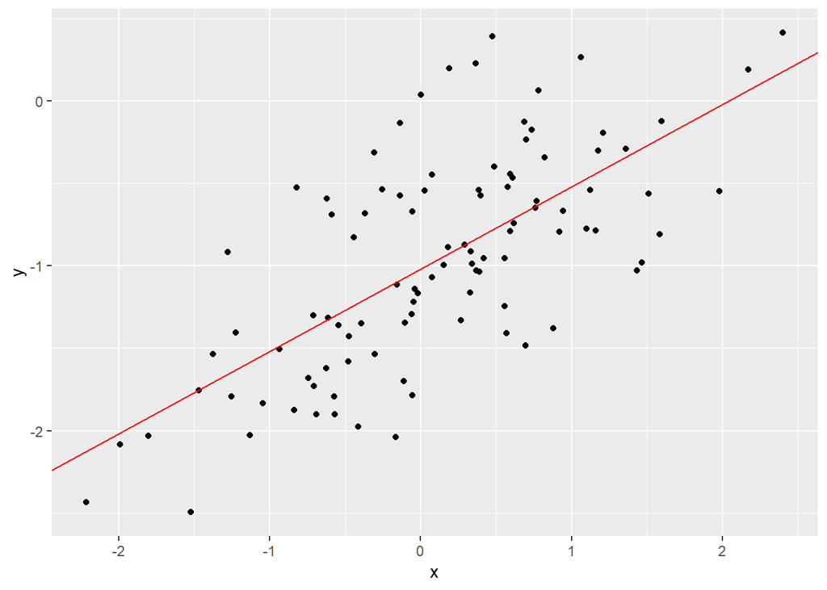

```r
data.frame(y=y, x=x) %>% ggplot(aes(x,y))+ geom_point()+ geom_abline(slope=beta_hat_1_13e, intercept=beta_hat_0_13e, col="RED", show.legend=TRUE)
```

# 13.g

```r
linear_fit_13g = lm(y~x+I(x^2))
summary_13g = summary(linear_fit_13g)
R_sq_13g = summary_13g$r.squared

#R-squared for fit with only linear term
R_sq_13e
```

```
## [1] 0.4673515
```

```r
#R-squared for fit with linear and quadratic term
R_sq_13g
```

```
## [1] 0.4779446
```

The R-squared value with the quadratic term is slightly better than the R-squared value with only a linear term. This is a classic example of “over-fitting”. The noise term eps means that y does not have a strict linear relationship with x and therefore the quadratic term helps create a more “wiggly” line that better fits the training data. However it is fully expected that with test data, the linear-term-only model would perform much better.

# 13.h

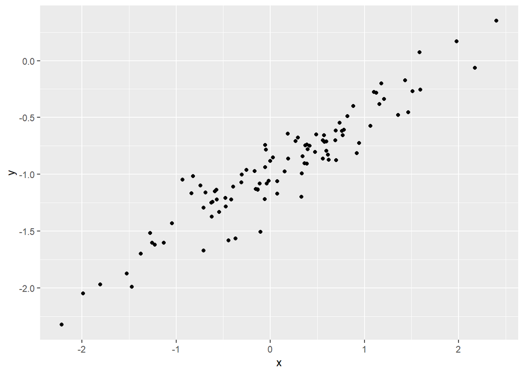

```r
eps_less = rnorm(100,0,sqrt(0.025))
y = -1+0.5*x+eps_less

data.frame(y=y, x=x) %>% ggplot(aes(x,y))+ geom_point()
```

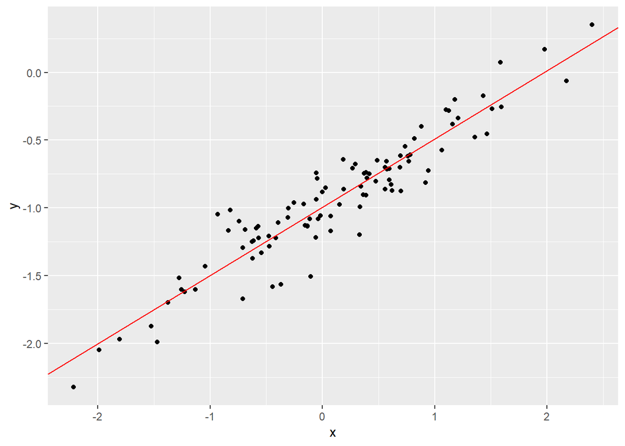

```r
linear_fit_13h = lm(y~x)
summary_13h = summary(linear_fit_13h)
beta_hat_0_13h = summary_13h$coefficients[1]
beta_hat_1_13h = summary_13h$coefficients[2]
R_sq_13h = summary_13h$r.squared

data.frame(y=y, x=x) %>% ggplot(aes(x,y))+ geom_point()+ geom_abline(slope=beta_hat_1_13h, intercept=beta_hat_0_13h, col="Red", show.legend=TRUE)
```

# 13.i

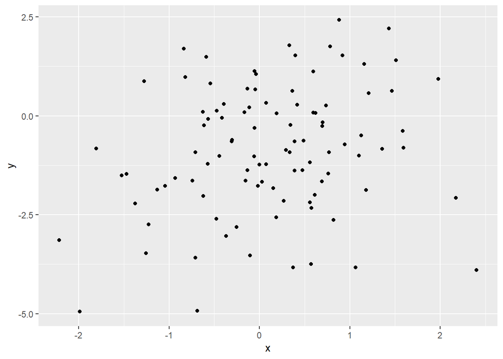

```r
eps_more = rnorm(100,0,sqrt(2.5))
y = -1+0.5*x+eps_more

data.frame(y=y, x=x) %>% ggplot(aes(x,y))+ geom_point()
```

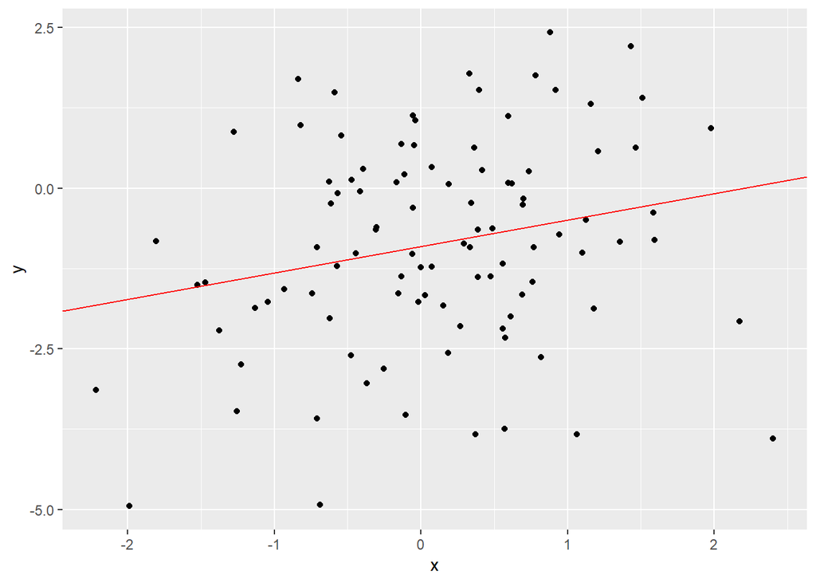

```r
linear_fit_13i = lm(y~x)
summary_13i = summary(linear_fit_13i)
beta_hat_0_13i = summary_13i$coefficients[1]
beta_hat_1_13i = summary_13i$coefficients[2]
R_sq_13i = summary_13i$r.squared

data.frame(y=y, x=x) %>% ggplot(aes(x,y))+ geom_point()+ geom_abline(slope=beta_hat_1_13i, intercept=beta_hat_0_13i, col="Red", show.legend=TRUE)
```